# Inapplicable data with the Fitch algorithm

Martin R. Smith

2018-03-09

```
## Reading data from ../Hyoliths/mbank_X24932_3-5-2018_643_no_notes.nex
```

# Parsimony analysis

The phylogenetic dataset contains a high proportion of inapplicable codings (404/3325 = 12% of tokens), which are known to introduce error and bias to phylogenetic reconstruction ((Brazeau, Guillerme, & Smith, 2017; Maddison, 1993)). As such, phylogenetic search employed a new algorithm that correctly handles inapplicable data (Brazeau et al., 2017). This algorithm is implemented in the *MorphyLib* C library (Brazeau, Smith, & Guillerme, 2017), and phylogenetic search was conducted using the *R* package *TreeSearch* v0.0.8 ((Smith, 2018)).

Heuristic searches were conducted using the parsimony ratchet (Nixon, 1999) under equal and implied weights (Pablo A. Goloboff, 1997) with a variety of concavity constants. The consensus tree presented in the main manuscript represents a strict consensus of all trees that are most parsimonious under one or more of the concavity constants (*k*) 2, 3, 4.5, 7, 10.5, 16 and 24, an approach that is known to produce higher accuracy than equal weights at any fixed level of precision (Smith, 2017).

The results of phylogenetic tree search under traditional algorithms in a parsimony an Bayesian framework are included in the supplementary information; these recover the same overall relationships but differ in the placement of a small number of incidental taxa.

# TNT

Parsimony search was conducted in TNT v1.5 (Pablo A Goloboff & Catalano, 2016) using sectorial and ratchet heuristics under equal and implied weights. We acknowledge the Willi Hennig Society for their sponsorship of the TNT software.

## Implied weights

The consensus of all implied weights runs is not very well resolved:

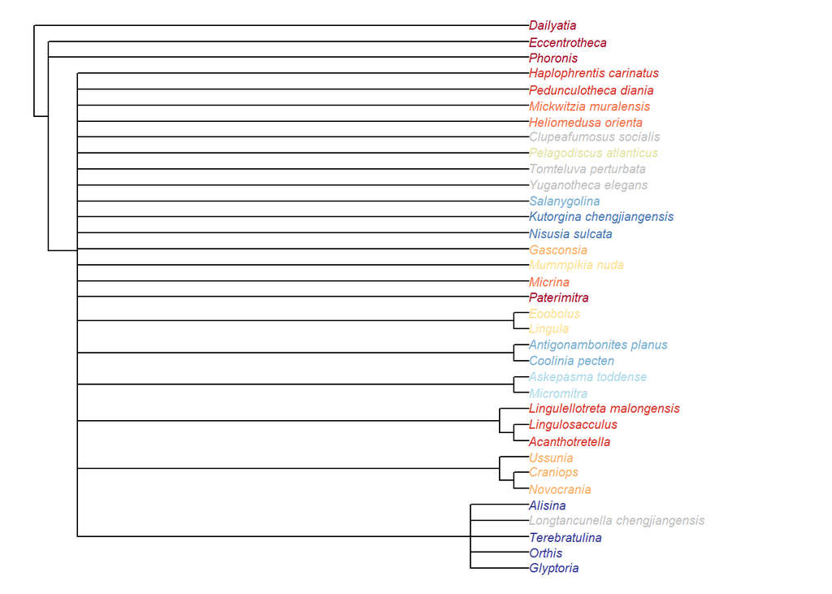

TNT implied weights consensus

This lack of resolution is largely a product of a few wildcard taxa, which obscure relationships that are nevertheless present in all most parsimonious trees:

### Paterinids included

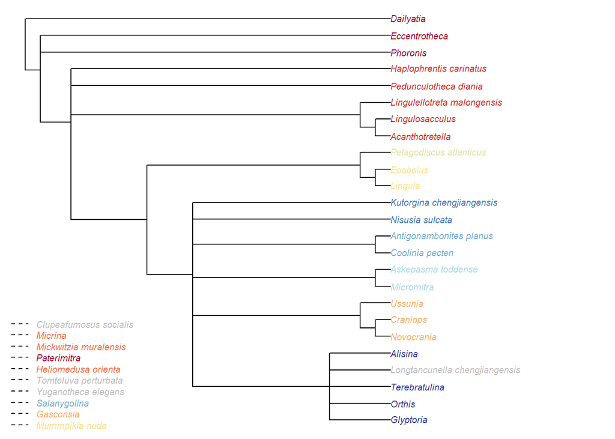

TNT implied weights consensus

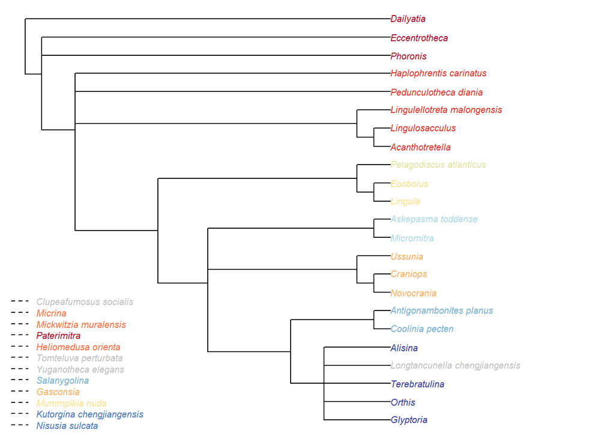

TNT implied weights consensus

## Equal weights

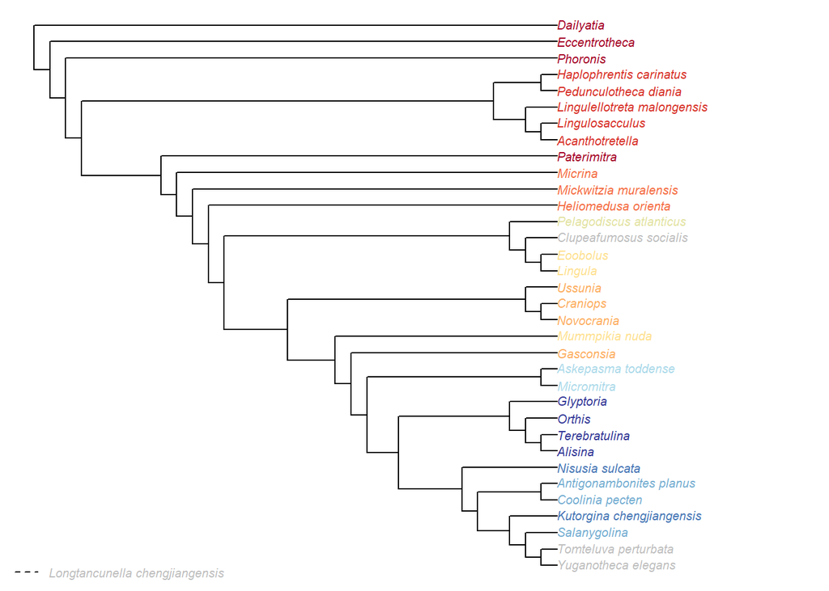

TNT Equal weights consensus

# Bayesian analysis

Bayesian search was conducted in MrBayes v3.2.6 (Ronquist et al., 2012) using the M_k_ model (Lewis, 2001) with a gamma parameter (`lset coding=variable rates=gamma;`). Branch length was drawn from a dirichlet prior distribution, which is less informative than an exponential model ((Rannala, Zhu, & Yang, 2012), but requires a prior mean tree length within about two orders of magnitude of the true value (Zhang, Rannala, & Yang, 2012). To satisfy this latter criterion, we specified the prior mean tree length to be equal to the length of the most parsimonious tree under equal weights (i.e. `prset brlenspr = unconstrained: gammadir(1,0.33,1,1);` $α_T = 1$, $β_T = 1/$(*equal weights tree length* / *number of characters*), $α = c = 1$).

Neomorphic and transformational characters (sensu Sereno, 2007) were allocated to two separate partitions whose proportion of invariant characters and gamma shape parameters were allowed to vary independently (`unlink shape=(all) pinvar=(all);`). Neomorphic characters were not assumed to have a symmetrical transition rate – that is, the probability of the absent → present transition was allowed to differ from that of the present → absent transition, being drawn from a uniform prior (`prset applyto=(`*number of Neomorphic partition*`) symdirihyperpr=fixed(1.0);`).

Two MrBayes runs were executed, each sampling eight chains for 400 000 generations, with samples taken every 250 generations. Convergence was indicated by PSRF = 1.00 and an estimated sample size of > 100 for each parameter. The first 10% of samples were discarded as burn-in, and a posterior tree topology was derived from the combined posterior sample of both runs.

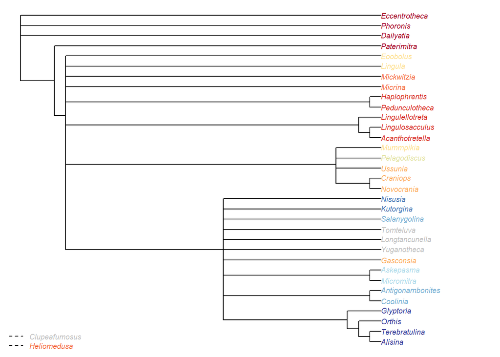

Bayesian analysis, posterior probability > 50%

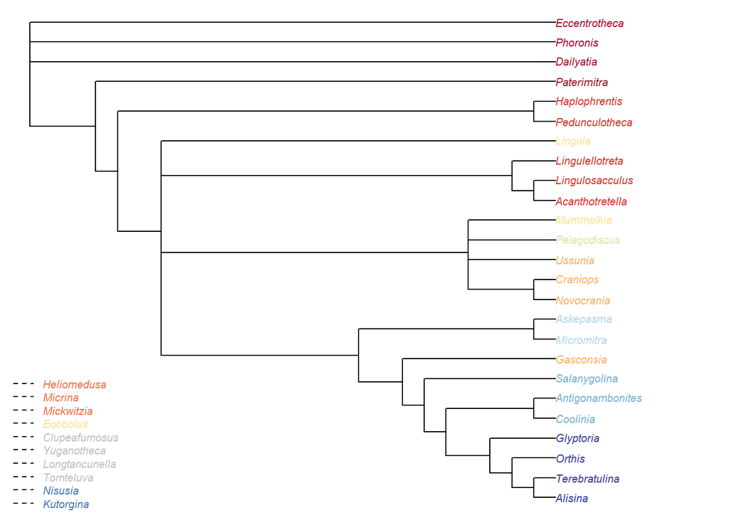

Bayesian analysis, posterior probability > 50%

# References

Brazeau, M. D., Guillerme, T., & Smith, M. R. (2017). Morphological phylogenetic analysis with inapplicable data. *bioR$\chi$iv*. doi:10.1101/209775

Brazeau, M. D., Smith, M. R., & Guillerme, T. (2017). MorphyLib: a library for phylogenetic analysis of categorical trait data with inapplicability. doi:10.5281/zenodo.815372

Goloboff, P. A. (1997). Self-weighted optimization: tree searches and character state reconstructions under implied transformation costs. *Cladistics*, *13*(3), 225–245. doi:10.1111/j.1096-0031.1997.tb00317.x

Goloboff, P. A., & Catalano, S. A. (2016). TNT version 1.5, including a full implementation of phylogenetic morphometrics. *Cladistics*, *32*(3), 221–238. doi:10.1111/cla.12160

Lewis, P. O. (2001). A likelihood approach to estimating phylogeny from discrete morphological character data. *Systematic Biology*, *50*(6), 913–925. doi:10.1080/106351501753462876

Maddison, W. P. (1993). Missing data versus missing characters in phylogenetic analysis. *Systematic Biology*, *42*(4), 576–581. doi:10.1093/sysbio/42.4.576

Nixon, K. C. (1999). The Parsimony Ratchet, a new method for rapid parsimony analysis. *Cladistics*, *15*(4), 407–414. doi:10.1111/j.1096-0031.1999.tb00277.x

Rannala, B., Zhu, T., & Yang, Z. (2012). Tail Paradox, Partial Identifiability, and Influential Priors in Bayesian Branch Length Inference. *Molecular Biology and Evolution*, *29*(1), 325–335. doi:10.1093/molbev/msr210

Ronquist, F., Teslenko, M., Mark, P. van der, Ayres, D. L., Darling, A., Hohna, S., … Huelsenbeck, J. P. (2012). MrBayes 3.2: Efficient Bayesian phylogenetic inference and model choice across a large model space. *Systematic Biology*, *61*(3), 539–42.

Sereno, P. C. (2007). Logical basis for morphological characters in phylogenetics. *Cladistics*, *23*(6), 565–587. doi:10.1111/j.1096-0031.2007.00161.x

Smith, M. R. (2017). Quantifying and visualising divergence between pairs of phylogenetic trees: implications for phylogenetic reconstruction. *bioR$\chi$iv*. doi:10.1101/227942

Smith, M. R. (2018). TreeSearch 0.0.8. doi:10.5281/zenodo.1194595

Zhang, C., Rannala, B., & Yang, Z. (2012). Robustness of compound Dirichlet priors for Bayesian inference of branch lengths, *61*(5), 779–84. doi:10.1093/sysbio/sys030